# Urban Ministries Project 3

Amber Young

11/18/2019

# Introduction

Urban Ministries, established in 1983, offers many programs to help support homeless and low-income people in the Durham community. These programs include:

- A community shelter, which can accomodate over 140 people a night
- A community cafe, which offers breakfast, lunch, and dinner daily to the homeless
- A food pantry, that provides people with groceries, and
- A clothing closet, that supplies individuals and families with clothing each month.

All together this organization helps about 6,000 people per year with over 4,000 volunteers, and they rely heavily on donations of food and clothing from the community.

This data, provided by Urban Ministries, focuses on their emergency shelter program.

# Purpose

The purpose of this project is to provide UM with summary statistics and plots describing the characteristics of people who have used their emergency shelter. Hopefully, with this information, UM can target its services to better serve its clients.

# The Data

The data, provided by Urban Ministries, focuses on their emergency shelter program, and can be found here:

https://github.com/biodatascience/datasci611/tree/gh-pages/data/project2_2019

## Useful Variables

Some of the most interesting outcome variables for this project include: Entry Date, Exit Date, and Reason For Leaving. From the dates we can calculate the length of stay for each person. The “Reason for Leaving” variable includes information on whether a client completed the program set out for them at UM.

The data also includes characteristics of shelter clients, such as: disability status, age, gender, race, ethnicity, veteran status, etc. These will be very useful in calculating summary statistics about what type of people are clients at UM.

# Characteristics of Urban Ministries Shelter Clients

This section provides some general information about the characteristics of UM Clients.

## Age

In the plot below, we have the number of UM Clients by age at entry to the shelter. We can see that almost all are under 60 years old and the majority are between 40 and 60. There is also a large amount of people in their 20s.

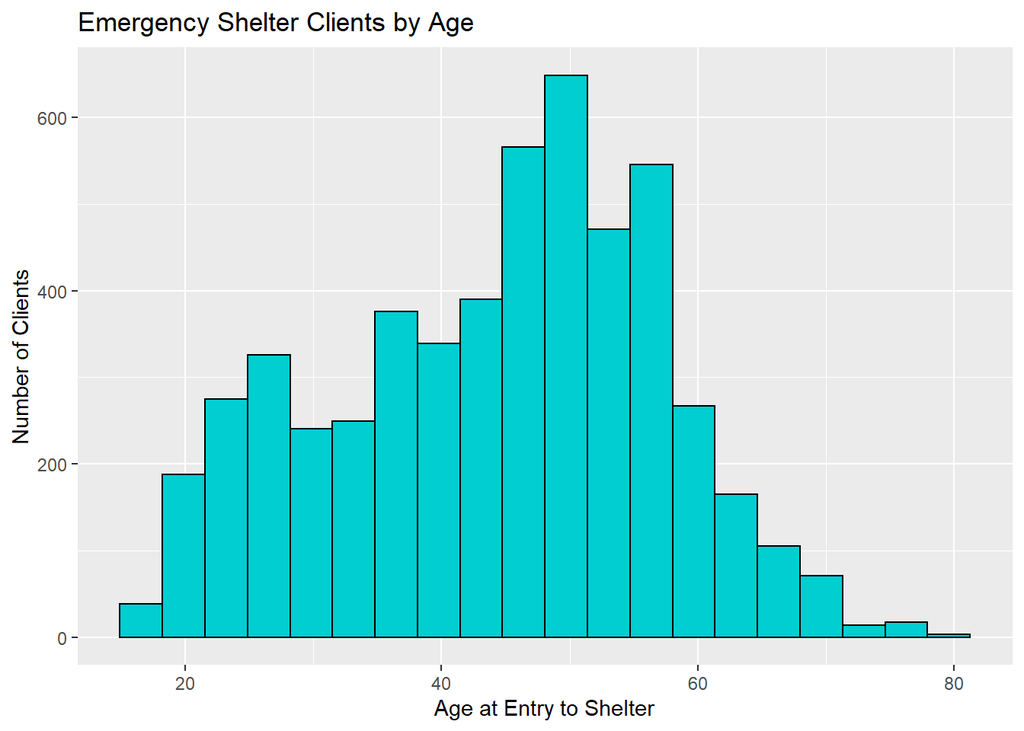

## Gender

We can see below that the UM shelter serves a much larger proportion of Males than Females, with the male clientele representing over 70%. We can also see that they serve a few from the transgender community.

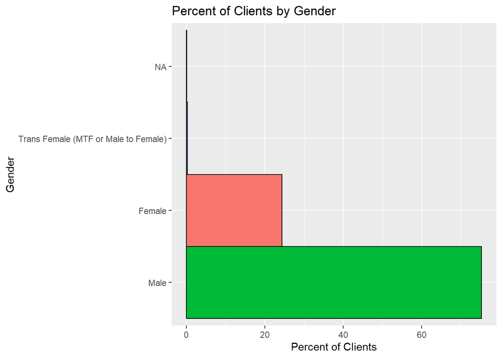

## Race

We can see below that there is a much large percentage of Black/African American clients at UM shelters than White clients. There are also a few American Indian/Alaskan Natives who have used the shelter.

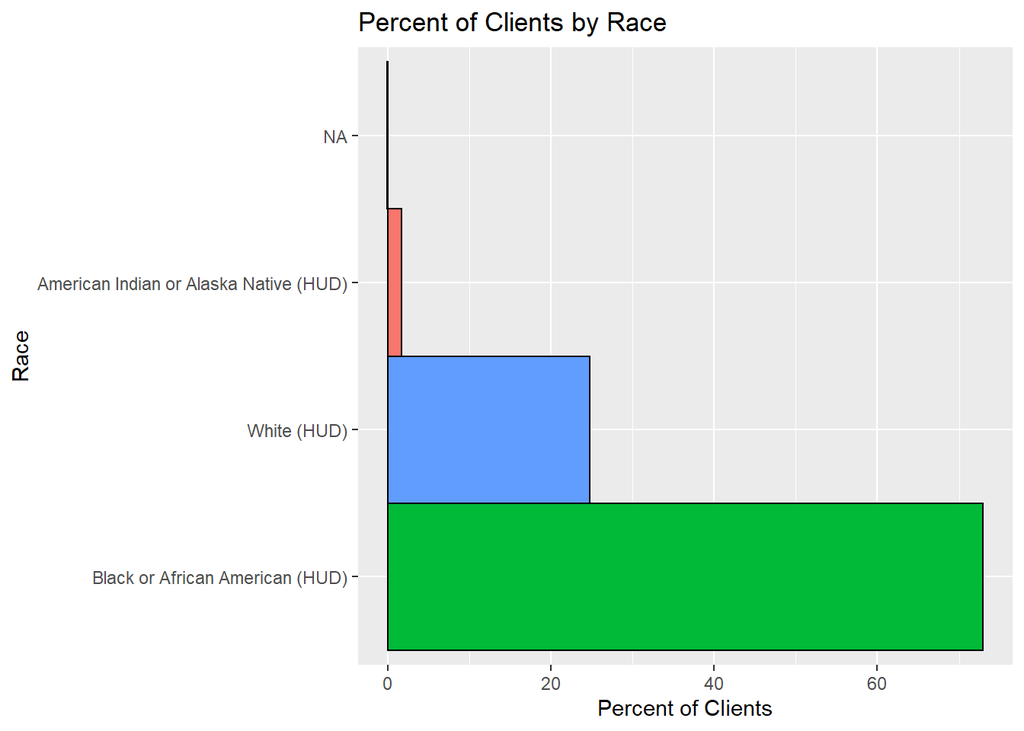

## Disability Status

This plot shows the percentage of clients who do or do not have some form of disability. We can see that there are more disabled people using the shelter than not disabled people.

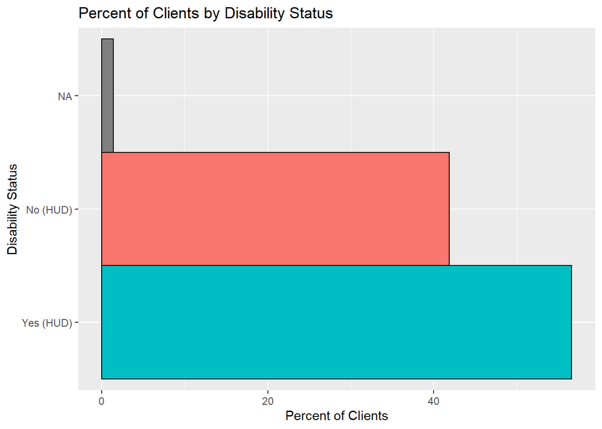

## Reason for Leaving the Shelter

This plot shows the percent of clients who leave the shelter by their reason for leaving. We can see that a large number of them just disappear (over 20%), 10% of them complete the UM program, about 8% leave for a housing opportunity, and the rest leave for a variety of other reasons.

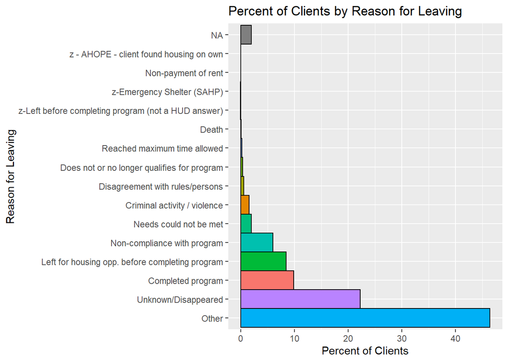

## Length of Stay at Shelter

```
##    Min. 1st Qu.  Median    Mean 3rd Qu.    Max.    NA's
##    1.00    5.00   16.00   39.71   45.00  894.00     107
```

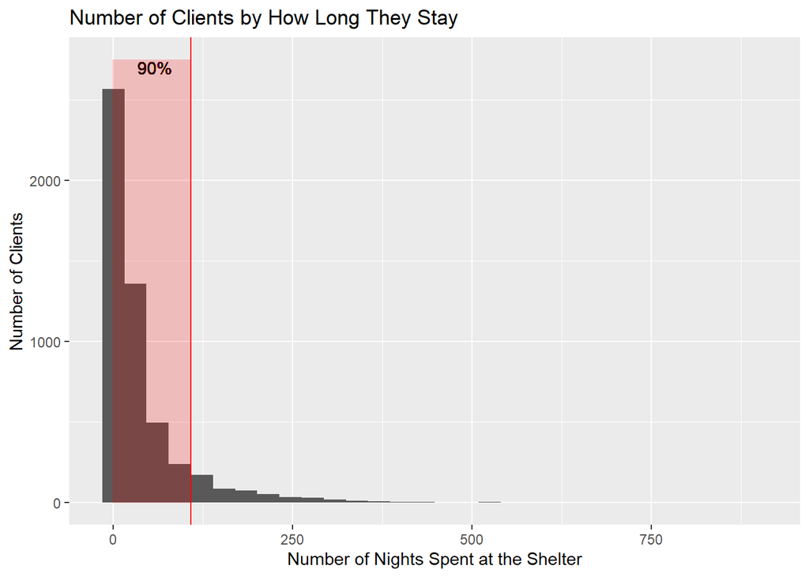

# Conclusions

Urban Ministries serves a diverse clientele, but some characteristics are more common than others. Knowing this can help them better prepare their facilities for the specific type of clients they see. For example, the majority of their clients are between 40 and 60 years old, and over half of them are disabled in some way. Therefore, job resources they might offer need to target to this slightly older age group, and to those that may be limited either physically or mentally. Additionally, the overwhelming majority of clients are black/African American. This information is very powerful in bringing to light the socioeconomic disparity between races in the Durham area. Finally, this project shows that a large number of people are disappearing from the shelter without finding housing or completing the UM program, and we see that most people don’t stay at the shelter very long.